# Assignment 5: Mixed models

##### Mindfulness

```r
range(a_raw_data$mindfulness)
```

```
## [1] 1.00 5.58
```

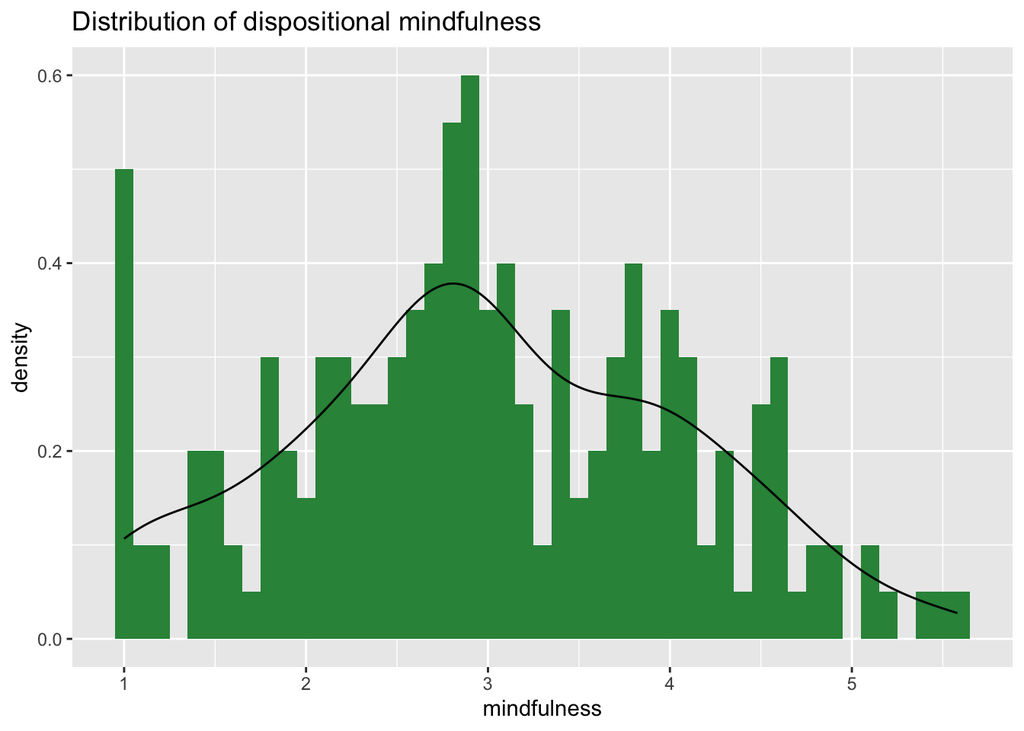

```r
# Range is between 1.00 and 5.58, which is in connection with the theoretical range of 1-6.

ggplot(a_raw_data, aes(x = mindfulness)) +
  geom_histogram(aes(y = after_stat(density)),
                 binwidth = 0.1,
                 fill = "#2f9147") +
  geom_density() +
  labs(title = "Distribution of dispositional mindfulness")
```

The distribution of dispositional mindfulness was visualized using a histogram. In order to show the shape of the distribution more smoothly, a density line was added to the histogram. Most observations are concentrated between approximately 2.5 and 4, indicating mild levels of dispositional mindfulness in the sample. Considerably high values are relatively infrequent, no clear extreme outliers can be detected.

#### 2.3. Hormonal variables - cortisol

The distributions of `cortisol_serum` and `cortisol_saliva` were also visualized with a faceted histograms and density curves.

```r
cortisol_data <- a_raw_data %>%
  select(cortisol_serum, cortisol_saliva) %>%
  pivot_longer(cols = everything(),
               names_to = "type",
               values_to = "cortisol")
```

Here, the data was formatted in order to create the plot.

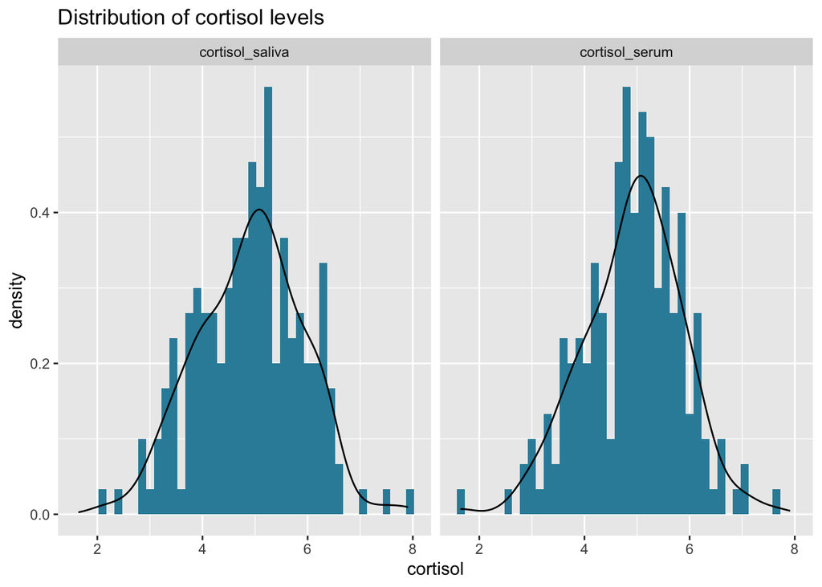

```r
ggplot(cortisol_data, aes(x = cortisol)) +
  geom_histogram(aes(y = after_stat(density)),
                 binwidth = 0.15,
                 fill = "#328da8") +
  geom_density() +
  facet_wrap(~ type) +
  labs(title = "Distribution of cortisol levels")
```

#### 2.4. Demographic variables

Finally, the distributions of the following demographic variables were visualized: * age, * sex, * and weight.

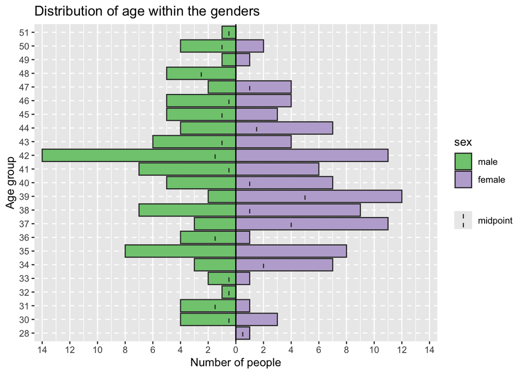

```r
age_sex_data <- a_raw_data %>%
  select(age, sex) %>%
  mutate(age = as.factor(age)) %>%
  mutate(sex = recode(sex, "Male" = "male"))

age_pyramid(age_sex_data, age_group = age, split_by = sex) +
      labs(x = "Age group",
          y = "Number of people",
          title = "Distribution of age within the genders")
```

The age distribution of participants was visualized separately for female and male participants. Ages ranged approximately from 28 to 51 years. The distributions for males and females appear to be similar, no clear systematic difference can be observed.

Visualization of weight within males and females:

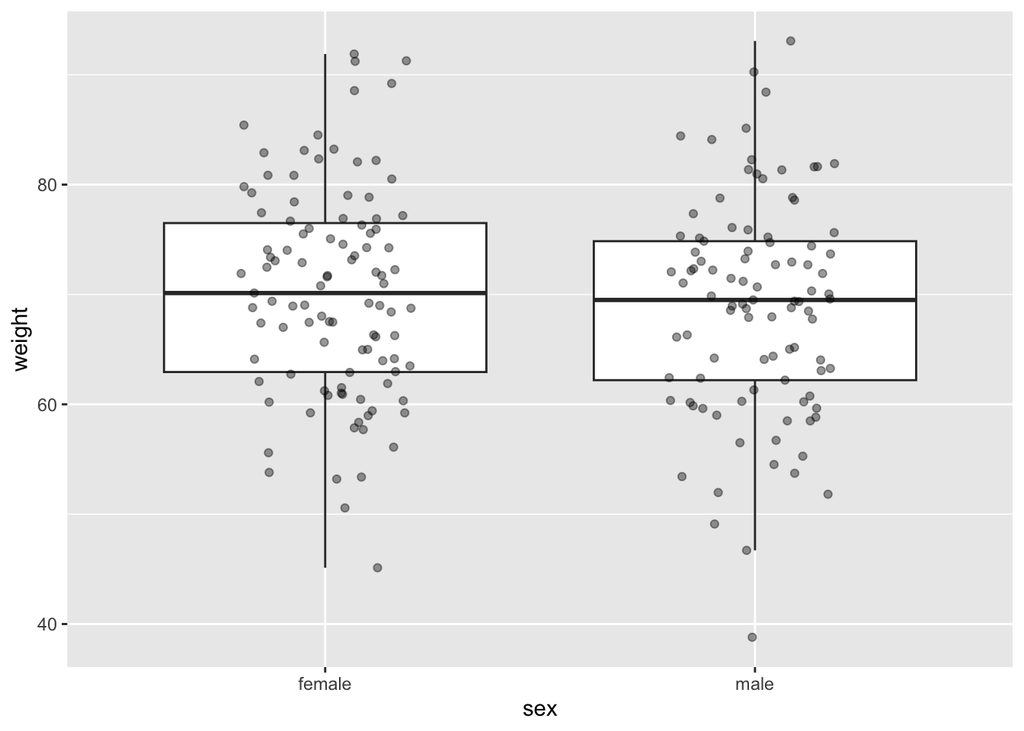

```r
sex_weight_data <- a_raw_data %>%
  select(weight, sex) %>%
  mutate(sex = recode(sex, "Male" = "male"))

ggplot(sex_weight_data, aes(x = sex, y = weight)) +
  geom_boxplot(outlier.shape = NA) +
  geom_jitter(width = 0.2,
              alpha = 0.4)
```

### 3. Bivariate relationships - pain and predictors

#### 3.1. Pain ~ STAI_trait

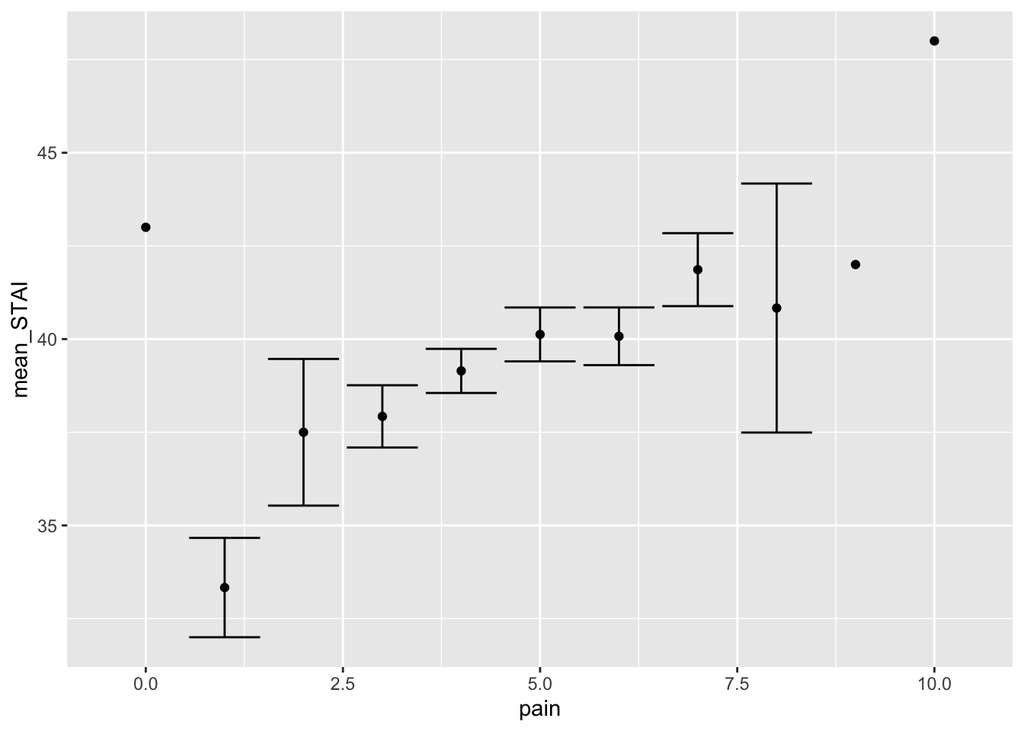

```r
stai_pain_data <- a_raw_data %>%
  group_by(pain) %>%
  summarise(mean_STAI = mean(STAI_trait),
            se = sd(STAI_trait)/sqrt(n()))
  ggplot(stai_pain_data, aes(x = pain, y = mean_STAI)) +
  geom_point() +
  geom_errorbar(aes(ymin = mean_STAI - se,
                    ymax = mean_STAI + se))
```

For each pain level (1-10), the average STAI (trait anxiety) was plotted, with the error bars. A positive trend is visible, which suggests that lower pain is associated with lower anxiety, while as pain increases, anxiety also increases.

#### 3.2. Pain ~ pain_cat

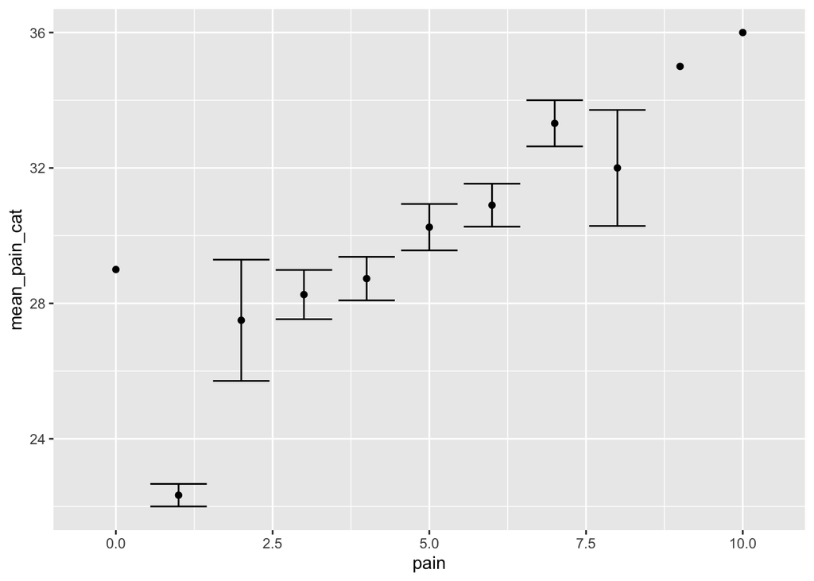

```r
pain_cat_data <- a_raw_data %>%
  group_by(pain) %>%
  summarise(mean_pain_cat = mean(pain_cat),
            se = sd(pain_cat)/sqrt(n()))

 ggplot(pain_cat_data, aes(x = pain, y = mean_pain_cat)) +
  geom_point() +
  geom_errorbar(aes(ymin = mean_pain_cat - se,
                    ymax = mean_pain_cat + se))
```

The plot visualizes mean pain catastrophizing for each pain level, with error bars. As pain increases, mean pain catastrophizing also increases, which shows a clean positive relationship. Some variablity is present at certain pain levels - this might reflect differences in sample size across categories.

#### 3.3. Pain ~ mindfulness

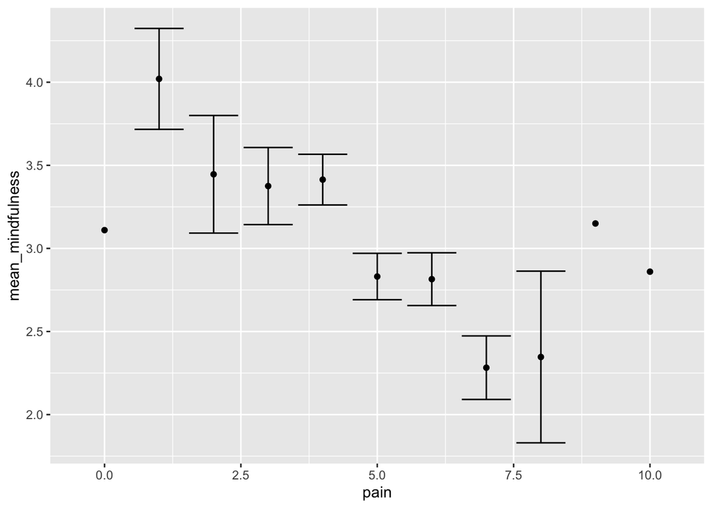

```r
mindfulness_data <- a_raw_data %>%
  group_by(pain) %>%
  summarise(mean_mindfulness = mean(mindfulness),
            se = sd(mindfulness)/sqrt(n()))

 ggplot(mindfulness_data, aes(x = pain, y = mean_mindfulness)) +
  geom_point() +
  geom_errorbar(aes(ymin = mean_mindfulness - se,
                    ymax = mean_mindfulness + se))
```

#### 3.4. Pain ~ cortisol_serum & Pain ~ cortisol_saliva

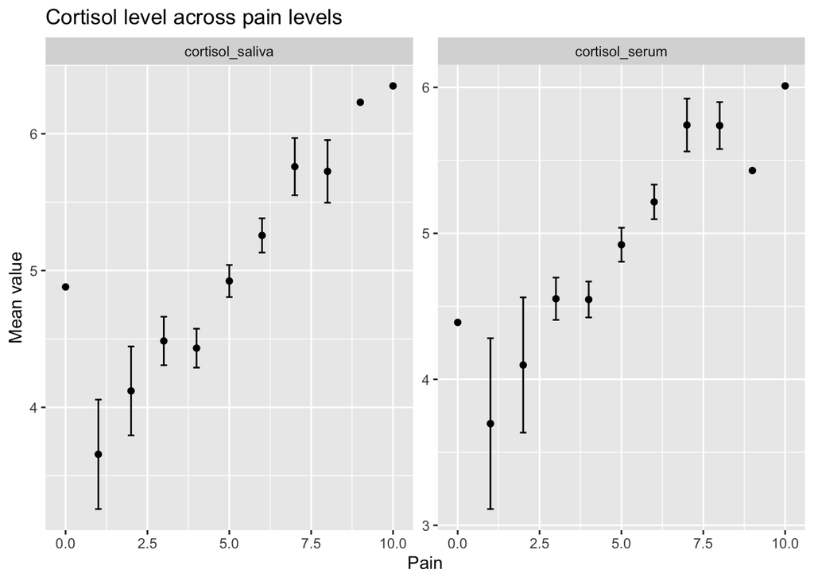

```r
cortisol_long_data <- a_raw_data %>%
  select(pain, cortisol_serum, cortisol_saliva) %>%
  pivot_longer(
    cols = -pain,
    names_to = "variable",
    values_to = "value"
  )

cortisol_summary_data <- cortisol_long_data %>%
  group_by(variable, pain) %>%
  summarise(
    mean_value = mean(value, na.rm = TRUE),
    se = sd(value, na.rm = TRUE) / sqrt(n()),
    .groups = "drop"
  )

ggplot(cortisol_summary_data, aes(x = pain, y = mean_value)) +
  geom_point() +
  geom_errorbar(aes(ymin = mean_value - se,
                    ymax = mean_value + se),
                width = 0.2) +
  facet_wrap(~ variable, scales = "free_y") +
  labs(
    title = "Cortisol level across pain levels",
    x = "Pain",
    y = "Mean value"
  )
```

In both panels, a clear positive trend is observed: higher pain levels are associated with higher average cortisol levels.

### 4. Relationships among predictors

Predictors are the following: * `STAI_trait` * `pain_cat` * `mindfulness` * `cortisol_serum` * `cortisol_saliva` * `age` * `weight`

In order to investigate the relationships between the predictors, a correlation matrix was created.

```r
cor_data <- a_raw_data %>%
  select(STAI_trait, pain_cat, mindfulness,
         cortisol_serum, cortisol_saliva,
         age, weight)

cor_matrix <- cor(cor_data, use = "complete.obs")

cor_matrix
```

```
##                  STAI_trait   pain_cat mindfulness cortisol_serum
## STAI_trait       1.00000000  0.5046613 -0.34335918     0.48986914
## pain_cat         0.50466134  1.0000000 -0.56660008     0.38200518
## mindfulness     -0.34335918 -0.5666001  1.00000000    -0.22025899
## cortisol_serum   0.48986914  0.3820052 -0.22025899     1.00000000
## cortisol_saliva  0.52098011  0.3146115 -0.25265263     0.88190933
## age              0.08442875 -0.1714817  0.04404146    -0.23178450
## weight          -0.07786800 -0.1251127  0.13558433    -0.03860455
##                 cortisol_saliva         age      weight
## STAI_trait           0.52098011  0.08442875 -0.07786800
## pain_cat             0.31461153 -0.17148172 -0.12511268
## mindfulness         -0.25265263  0.04404146  0.13558433
## cortisol_serum       0.88190933 -0.23178450 -0.03860455
## cortisol_saliva      1.00000000 -0.33268616 -0.01642476
## age                 -0.33268616  1.00000000 -0.11149708
## weight              -0.01642476 -0.11149708  1.00000000
```

Visualization:

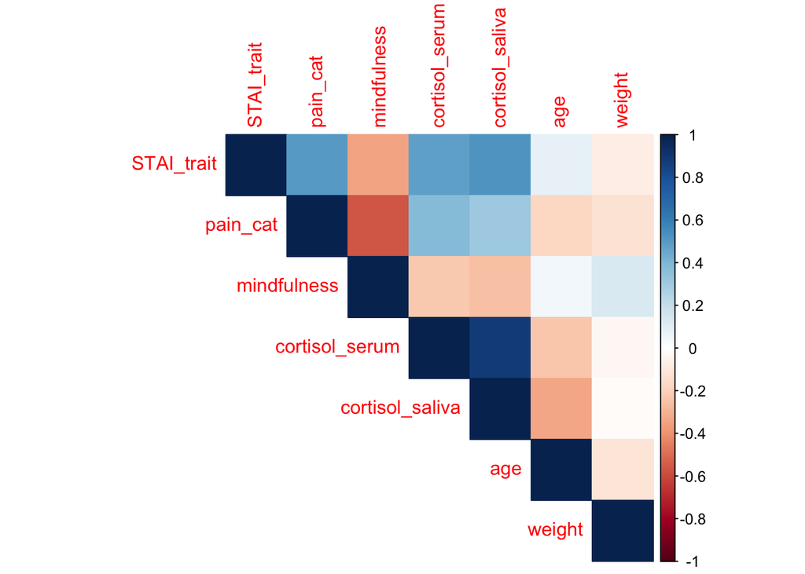

```r
corrplot(cor_matrix, method = "color", type = "upper")
```

### 5. Differences between hospital sites

In order to assess the potential differences between the hospital sites with regards to the outcome variable (pain), the pain levels were examined across the hospital sites.

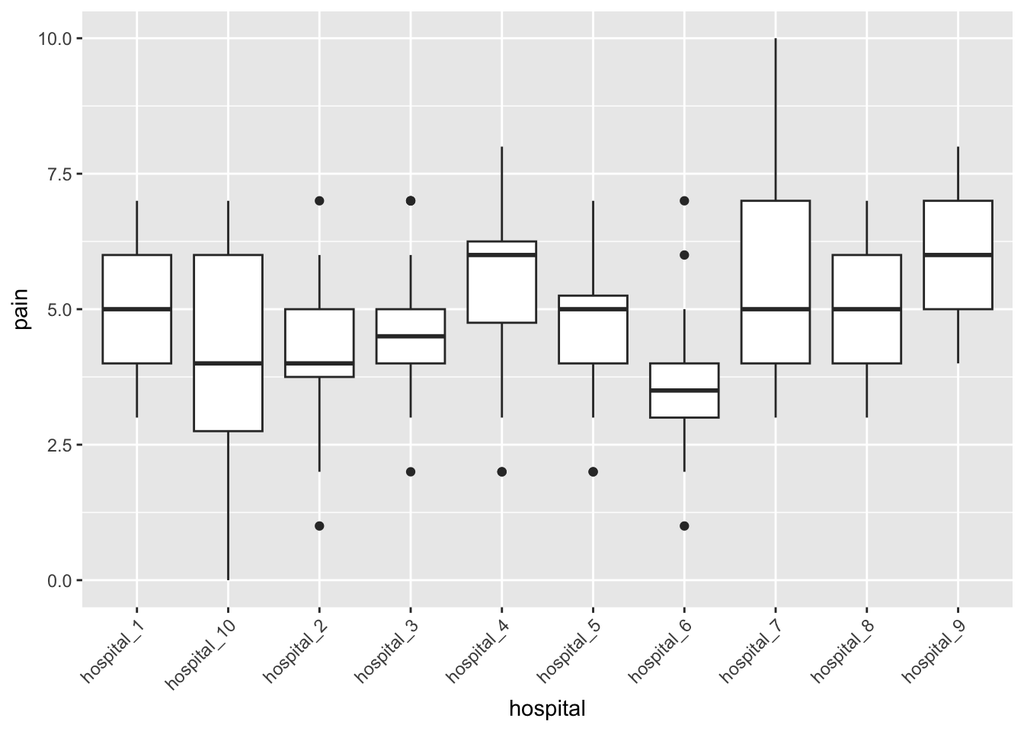

```r
ggplot(a_raw_data, aes(x = hospital, y = pain)) +
  geom_boxplot() +
  theme(axis.text.x = element_text(angle = 45, hjust = 1))
```

Based on the boxplot, a small level of variation between hospital sites can be observed; however, the differences appear to be relatively moderate.

Before modeling, search answers for: - should I transform (log)? - should i stardardize predictors?

## =============================================================

## Correct coding errors

If you find values in the dataset during the EDA, that are not correct based on the provided descriptions of the variables of the dataset please correct them here.

```r
a_raw_data <- a_raw_data %>%
  mutate(sex = recode(sex, "Male" = "male"),
         hospital = as.factor(hospital))
```

## =============================================================

## Linear Mixed Model on Dataset A

```r
model_A <- lmer(
  pain ~ age + sex + STAI_trait + pain_cat + mindfulness + cortisol_serum +
    (1 | hospital),
  data = a_raw_data
)
```

1. Fixed effects results Extracting the coefficients and the CIs:

```r
summary(model_A)
```

```
## Linear mixed model fit by REML. t-tests use Satterthwaite's method [
## lmerModLmerTest]
## Formula:
## pain ~ age + sex + STAI_trait + pain_cat + mindfulness + cortisol_serum +
##     (1 | hospital)
##    Data: a_raw_data
##
## REML criterion at convergence: 682.6
##
## Scaled residuals:
##      Min       1Q   Median       3Q      Max
## -3.10080 -0.67358  0.05678  0.66353  2.78802
##
## Random effects:
##  Groups   Name        Variance Std.Dev.
##  hospital (Intercept) 0.3131   0.5596
##  Residual             1.4866   1.2193
## Number of obs: 200, groups:  hospital, 10
##
## Fixed effects:
##                  Estimate Std. Error         df t value Pr(>|t|)
## (Intercept)      3.502306   1.380454 192.019684   2.537  0.01197 *
## age             -0.054400   0.019818 189.297615  -2.745  0.00664 **
## sexmale          0.297545   0.190460 187.406434   1.562  0.11992
## STAI_trait       0.001437   0.023851 185.932388   0.060  0.95202
## pain_cat         0.036885   0.028633 187.343455   1.288  0.19926
## mindfulness     -0.262441   0.100647 187.056391  -2.608  0.00986 **
## cortisol_serum   0.610010   0.114260 186.705239   5.339  2.7e-07 ***
## ---
## Signif. codes:  0 '***' 0.001 '**' 0.01 '*' 0.05 '.' 0.1 ' ' 1
##
## Correlation of Fixed Effects:
##             (Intr) age    sexmal STAI_t pan_ct mndfln
## age         -0.626
## sexmale      0.144 -0.206
## STAI_trait  -0.104 -0.321  0.214
## pain_cat    -0.552  0.269 -0.358 -0.400
## mindfulness -0.569  0.056 -0.076  0.032  0.483
## cortisl_srm -0.224  0.261  0.001 -0.416 -0.078  0.003
```

```r
confint(model_A, method = "Wald")
```

```
##                      2.5 %      97.5 %
## .sig01                  NA          NA
## .sigma                  NA          NA
## (Intercept)     0.79666571  6.20794562
## age            -0.09324285 -0.01555684
## sexmale        -0.07574983  0.67083962
## STAI_trait     -0.04531105  0.04818505
## pain_cat       -0.01923450  0.09300448
## mindfulness    -0.45970466 -0.06517714
## cortisol_serum  0.38606414  0.83395592
```

The variance of the random intercept of hospital (σ² = 0.31) was smaller than the residual variance, indicating that majority of the variability in pain occured at the individual-level.

```r
tidy_model <- broom.mixed::tidy(model_A, effects = "fixed", conf.int = TRUE)

library(knitr)
tidy_model %>%
  mutate(
    estimate = round(estimate, 2),
    conf.low = round(conf.low, 2),
    conf.high = round(conf.high, 2),
    p.value = round(p.value, 3)
  ) %>%
  select(term, estimate, conf.low, conf.high, p.value) %>%
  rename(
    Predictor = term,
    Beta = estimate,
    `CI Lower` = conf.low,
    `CI Upper` = conf.high,
    `p-value` = p.value
  ) %>%
  knitr::kable(caption = "Fixed effects of the linear mixed-effects model")
```

Fixed effects of the linear mixed-effects model

| Predictor | Beta | CI Lower | CI Upper | p-value |
| --- | --- | --- | --- | --- |
| (Intercept) | 3.50 | 0.78 | 6.23 | 0.012 |
| age | -0.05 | -0.09 | -0.02 | 0.007 |
| sexmale | 0.30 | -0.08 | 0.67 | 0.120 |
| STAI_trait | 0.00 | -0.05 | 0.05 | 0.952 |
| pain_cat | 0.04 | -0.02 | 0.09 | 0.199 |
| mindfulness | -0.26 | -0.46 | -0.06 | 0.010 |
| cortisol_serum | 0.61 | 0.38 | 0.84 | 0.000 |

The fixed effect estimates of the model are presented in the table, including the Beta values, the 95% confidence intervals, and the p values.

Variance components:

```r
VarCorr(model_A)
```

```
##  Groups   Name        Std.Dev.
##  hospital (Intercept) 0.55956
##  Residual             1.21928
```

The standard deviation of the random intercept was 0.56, and the residual standard deviation was 1.22.

Marginal and Conditional R squared

```r
r2_values <- performance::r2(model_A)
r2_values
```

```
## # R2 for Mixed Models
##
##   Conditional R2: 0.436
##      Marginal R2: 0.317
```

The marginal R squared indicated that 31.7% of the variance was explained by the fixed effect predictors. The conditional R was higher (43.6%), suggesting that the random intercept structure improved the model (this model explains the variance in a stronger manner).

## =============================================================

## DATASET B

Importing the data:

```r
b_raw_data <- haven::read_spss("../data/assignment_4_dataset_B.sav")
```

Generating predictions:

```r
predict_b <- predict(model_A, newdata = b_raw_data, re.form = NA)
```

In order to evaluate the generalizability of the model used on dataset A, predictions were generated for dataset B, using the fixed effects estimated from dataset A.

Computing R squared:

```r
RSS <- sum((b_raw_data$pain - predict_b)^2)
TSS <- sum((b_raw_data$pain - mean(b_raw_data$pain))^2)
R2_B <- 1 - (RSS / TSS)
R2_B
```

```
## [1] 0.3497686
```